# Exam #2

# COURSE_EVAL + PROF_EVAL + PROF_AGE + SIZE + PROF_BEAUTY + CLASS_LEVEL_UPPER are all not significant predictors individually.

#### Part C

Construct and plot a logistic regression equation using PROF_GENDER_FEMALE as the response variable and PROF_AGE as the explanatory variable.

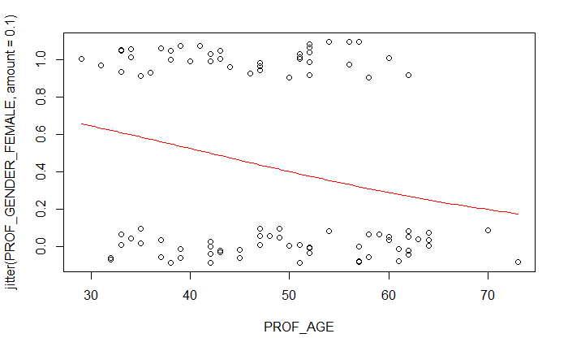

```r
mod2 = glm(PROF_GENDER_FEMALE ~ PROF_AGE, family=binomial, data=CourseEvals)
B0 = summary(mod2)$coef[1]
B1 = summary(mod2)$coef[2]
plot(jitter(PROF_GENDER_FEMALE, amount=.1)~PROF_AGE, data=CourseEvals)
curve(exp(B0+B1*x)/(1+exp(B0+B1*x)), add=TRUE, col="red")
```

#### Part D

Conduct a hypothesis test (listing the null and alternative hypotheses, value of the G test statistic, and p-value) to determine if the model constructed in Part A is significantly better than the model constructed in Part C for predicting the gender of a professor.

```r
summary(mod2)
```

```
Call:
glm(formula = PROF_GENDER_FEMALE ~ PROF_AGE, family = binomial,
    data = CourseEvals)

Deviance Residuals:
    Min       1Q   Median       3Q      Max
-1.3922  -1.0493  -0.7882   1.1811   1.6251

Coefficients:
            Estimate Std. Error z value Pr(>|z|)
(Intercept)  2.09401    1.04748   1.999   0.0456 *
PROF_AGE    -0.05006    0.02178  -2.298   0.0215 *
---
Signif. codes:  0 ‘***’ 0.001 ‘**’ 0.01 ‘*’ 0.05 ‘.’ 0.1 ‘ ’ 1

(Dispersion parameter for binomial family taken to be 1)

    Null deviance: 127.10  on 92  degrees of freedom
Residual deviance: 121.45  on 91  degrees of freedom
AIC: 125.45

Number of Fisher Scoring iterations: 4
```

```r
G = 127.10 - 121.45
print(G)
```

```
[1] 5.65
```

```r
1-pchisq(G, 1)
```

```
[1] 0.01745537
```

### Question 2

The Bears dataset contains data with bears’ age (in months), sex (1=male), various body measurements (in inches), and weight (in pounds).

#### Part A

Construct a multiple regression linear model to predict bears’ age with the *lowest Mallow’s Cp* using any/all of the variables. Do not use transformations, interactions, or second or greater order terms. Explain the process that you used to find this best model.

```r
library(readr)
library(leaps)
Bears <- read_csv("C:/Users/samee/Google Drive/College/STOR 455/R/Datasets/Bears.csv")
head(Bears)
```

| AGE | SEX | HEADLEN | HEADWDTH | NECK | LENGTH | CHEST | WEIGHT |
| --- | --- | --- | --- | --- | --- | --- | --- |
| 19 | 1 | 11.0 | 5.5 | 16.0 | 53.0 | 26 | 80 |
| 55 | 1 | 16.5 | 9.0 | 28.0 | 67.5 | 45 | 344 |
| 81 | 1 | 15.5 | 8.0 | 31.0 | 72.0 | 54 | 416 |
| 115 | 1 | 17.0 | 10.0 | 31.5 | 72.0 | 49 | 348 |
| 104 | 0 | 15.5 | 6.5 | 22.0 | 62.0 | 35 | 166 |
| 100 | 0 | 13.0 | 7.0 | 21.0 | 70.0 | 41 | 220 |

```r
all=regsubsets(AGE~SEX+HEADLEN+HEADWDTH+NECK+LENGTH+CHEST+WEIGHT,
        data=Bears, nbest=2)
ShowSubsets(all)
```

|  | SEX | HEADLEN | HEADWDTH | NECK | LENGTH | CHEST | WEIGHT | Rsq | adjRsq | Cp |
| --- | --- | --- | --- | --- | --- | --- | --- | --- | --- | --- |
| 1 ( 1 ) |  |  |  |  |  |  | * | 56.10 | 55.26 | 24.82 |
| 1 ( 2 ) |  |  |  |  | * |  |  | 51.66 | 50.73 | 32.39 |
| 2 ( 1 ) | * |  |  | * |  |  |  | 66.32 | 65.00 | 9.40 |
| 2 ( 2 ) | * |  |  |  |  |  | * | 66.18 | 64.85 | 9.65 |
| 3 ( 1 ) | * |  | * |  |  |  | * | 69.26 | 67.42 | 6.39 |
| 3 ( 2 ) | * | * |  |  |  |  | * | 68.97 | 67.10 | 6.90 |
| 4 ( 1 ) | * | * | * |  |  |  | * | 70.73 | 68.34 | 5.89 |
| 4 ( 2 ) | * | * |  |  |  | * | * | 70.62 | 68.22 | 6.08 |
| 5 ( 1 ) | * | * | * |  |  | * | * | 72.54 | 69.68 | 4.80 |
| 5 ( 2 ) | * | * |  | * |  | * | * | 71.64 | 68.68 | 6.34 |

[output cut: 3 more lines]

```r
trainBears = lm(AGE~WEIGHT+CHEST+HEADWDTH+HEADLEN+SEX,data=Bears)
```

I loaded the necessary packages. And used the allregsubsets method from the leaps package and then calculated the Mallow’s cp. From my calculations the best model has the following 5 predictors: WEIGHT, CHEST, HEADWDTH, HEADLEN, SEX. This model also has the best adjusted r-squared and fits the relationship the best.

#### Part B

A second sample of bears is contained in the dataset MoreBears. Use your best model from part (a) to predict the age of the bears in the MoreBears sample data. Calcuate the cross-validation correlation and shrinkage.

```r
library(readr)
MoreBears <- read_csv("C:/Users/samee/Google Drive/College/STOR 455/R/Datasets/MoreBears.csv")
fit = predict(trainBears, newdata=MoreBears)
cor(Bears$SEX[0:54], fit)
```

```
Error in cor(Bears$SEX[0:54], fit) : incompatible dimensions
```

### Question 3

The Penguins dataset contains data on the number of breeding pairs of penguins at Jardin Japonais on Possession Island, for 11 breeding seasons

#### Part A

Construct a linear model to predict the number of breeding pairs based on the year. Determine if year is a significant predictor in this model, citing your hypotheses and conclusion.

```r
library(readr)
Penguin <- read_csv("C:/Users/samee/Google Drive/College/STOR 455/R/Datasets/Penguin.csv")
head(Penguin)
```

| Year | Pairs |
| --- | --- |
| 1967 | 5000 |
| 1981 | 14700 |
| 1986 | 33000 |
| 1987 | 28000 |
| 1988 | 35100 |
| 1989 | 41600 |

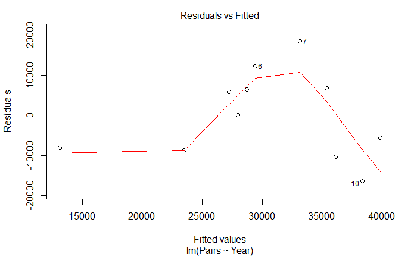

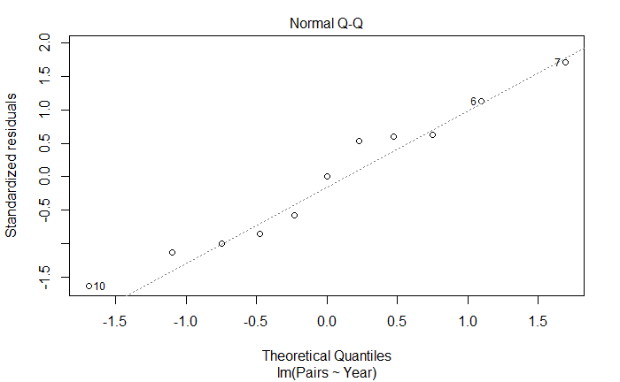

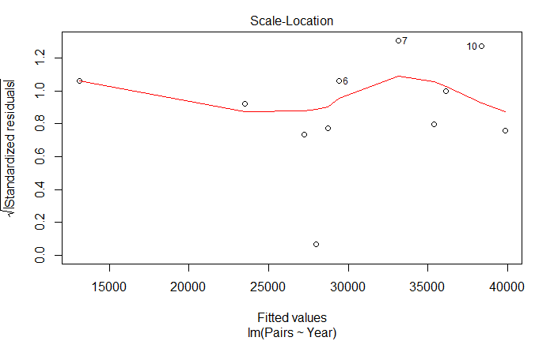

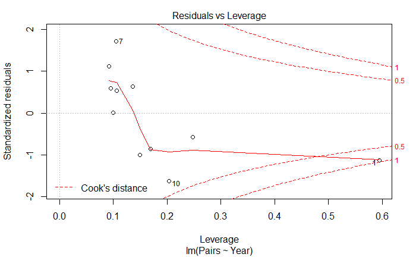

```r
mod3 = lm(Pairs~Year, data=Penguin)
plot(mod3)
```

```r
summary(mod3)
```

```
Call:
lm(formula = Pairs ~ Year, data = Penguin)

Residuals:
     Min       1Q   Median       3Q      Max
-16446.3  -8455.0     45.5   6529.5  18353.6

Coefficients:
              Estimate Std. Error t value Pr(>|t|)
(Intercept) -1446939.2   693569.5  -2.086   0.0666 .
Year             742.3      348.5   2.130   0.0620 .
---
Signif. codes:  0 ‘***’ 0.001 ‘**’ 0.01 ‘*’ 0.05 ‘.’ 0.1 ‘ ’ 1

Residual standard error: 11340 on 9 degrees of freedom
Multiple R-squared:  0.3351,    Adjusted R-squared:  0.2612
F-statistic: 4.536 on 1 and 9 DF,  p-value: 0.06204
```

The null hypothesis is that there is no linear relationship between the predictor and the response while the alternate is that there is a linear relationship. I would say that the model here is not signifianct because it’s p-value is above .05 (.06204). The Adjusted r-squared is also quite low as wel.

#### Part B

Analyze the residuals of the model and comment on the use of the simple linear model to predict breeding pairs.

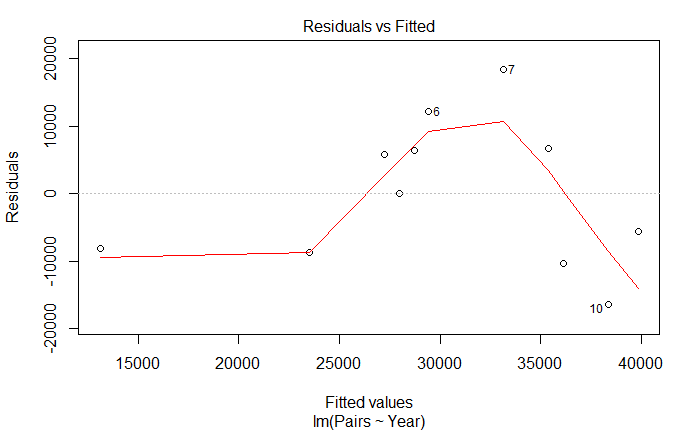

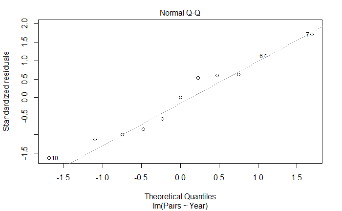

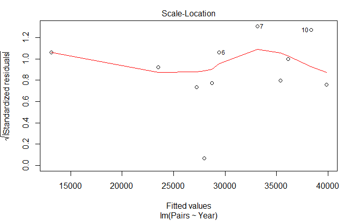

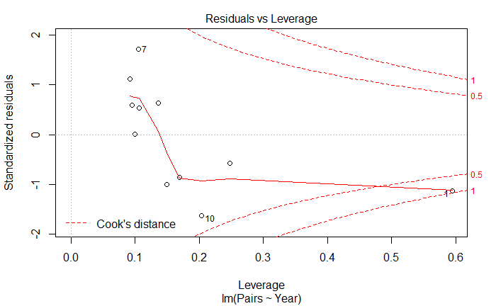

```r
plot(mod3)
```

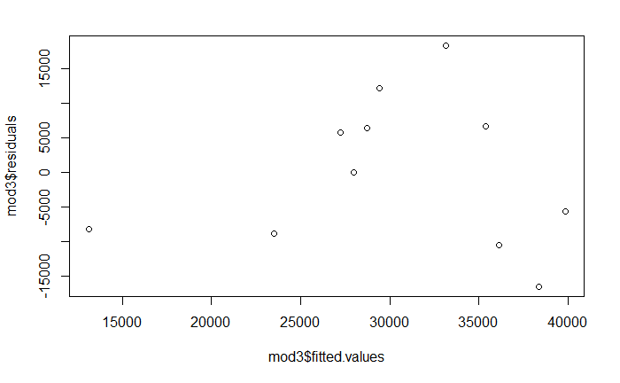

```r
plot(mod3$residuals ~ mod3$fitted.values)
```

We can see that the residuals are scattered a little in the residuals vs fitted values graph. However, there is a mountain shaped pattern in the graph, suggesting a revision in the model. The normal qq plot looks good except for a dip in the middle, suggesting a revision.

#### Part C

Construct a cubic model to predict the number of breeding pairs by year. Compare this to your original model in part A with a nested F test to determine if the added terms significantly improve the model. State your hypotheses and conclusion. **You do NOT need to plot the cubic model. You may run into issues displaying the curve due to rounding. You also do NOT need to examine the residuals**

```r
mod4 = lm(Pairs~I(Year^3), data=Penguin)
anova(mod3)
```

```
Analysis of Variance Table

Response: Pairs
          Df     Sum Sq   Mean Sq F value  Pr(>F)
Year       1  583424155 583424155  4.5363 0.06204 .
Residuals  9 1157509934 128612215
---
Signif. codes:  0 ‘***’ 0.001 ‘**’ 0.01 ‘*’ 0.05 ‘.’ 0.1 ‘ ’ 1
```

```r
anova(mod4)
```

```
Analysis of Variance Table

Response: Pairs
          Df     Sum Sq   Mean Sq F value  Pr(>F)
I(Year^3)  1  577536948 577536948  4.4678 0.06368 .
Residuals  9 1163397142 129266349
---
Signif. codes:  0 ‘***’ 0.001 ‘**’ 0.01 ‘*’ 0.05 ‘.’ 0.1 ‘ ’ 1
```

```r
anova(mod3, mod4)
```

```
Analysis of Variance Table

Model 1: Pairs ~ Year
Model 2: Pairs ~ I(Year^3)
  Res.Df        RSS Df Sum of Sq F Pr(>F)
1      9 1157509934
2      9 1163397142  0  -5887208
```